# Risk Factor Analysis

## Outcome Variable

**Outcome Variable:** wast_rec90d

## Predictor Variables

**Intervention Variable:** earlybf

**Adjustment Set:**

- arm
- sex
- W_mage
- meducyrs
- feducyrs
- hhwealth_quart
- hfoodsec
- W_mhtcm
- vagbrth
- W_birthwt
- W_birthlen
- W_nrooms
- W_nchldlt5
- brthmon
- W_parity
- impfloor
- impsan
- safeh20
- delta_W_mage
- delta_meducyrs
- delta_feducyrs
- delta_hhwealth_quart
- delta_hfoodsec
- delta_W_mhtcm
- delta_vagbrth
- delta_W_birthwt
- delta_W_birthlen
- delta_W_nrooms
- delta_W_nchldlt5
- delta_brthmon
- delta_W_parity
- delta_impfloor
- delta_impsan
- delta_safeh20

## Stratifying Variables

The analysis was stratified on these variable(s):

- agecat
- studyid
- country

## Data Summary

| agecat | studyid | country | earlybf | wast_rec90d | n_cell | n |
| --- | --- | --- | --- | --- | --- | --- |
| 0-24 months | ki0047075b-MAL-ED | BANGLADESH | 1 | 0 | 26 | 122 |
| 0-24 months | ki0047075b-MAL-ED | BANGLADESH | 1 | 1 | 46 | 122 |
| 0-24 months | ki0047075b-MAL-ED | BANGLADESH | 0 | 0 | 18 | 122 |
| 0-24 months | ki0047075b-MAL-ED | BANGLADESH | 0 | 1 | 32 | 122 |
| 0-24 months | ki0047075b-MAL-ED | BRAZIL | 1 | 0 | 3 | 23 |
| 0-24 months | ki0047075b-MAL-ED | BRAZIL | 1 | 1 | 5 | 23 |
| 0-24 months | ki0047075b-MAL-ED | BRAZIL | 0 | 0 | 3 | 23 |
| 0-24 months | ki0047075b-MAL-ED | BRAZIL | 0 | 1 | 12 | 23 |
| 0-24 months | ki0047075b-MAL-ED | INDIA | 1 | 0 | 44 | 178 |
| 0-24 months | ki0047075b-MAL-ED | INDIA | 1 | 1 | 62 | 178 |
| 0-24 months | ki0047075b-MAL-ED | INDIA | 0 | 0 | 27 | 178 |
| 0-24 months | ki0047075b-MAL-ED | INDIA | 0 | 1 | 45 | 178 |
| 0-24 months | ki0047075b-MAL-ED | NEPAL | 1 | 0 | 9 | 93 |
| 0-24 months | ki0047075b-MAL-ED | NEPAL | 1 | 1 | 33 | 93 |
| 0-24 months | ki0047075b-MAL-ED | NEPAL | 0 | 0 | 11 | 93 |
| 0-24 months | ki0047075b-MAL-ED | NEPAL | 0 | 1 | 40 | 93 |
| 0-24 months | ki0047075b-MAL-ED | PERU | 1 | 0 | 5 | 34 |
| 0-24 months | ki0047075b-MAL-ED | PERU | 1 | 1 | 25 | 34 |
| 0-24 months | ki0047075b-MAL-ED | PERU | 0 | 0 | 1 | 34 |
| 0-24 months | ki0047075b-MAL-ED | PERU | 0 | 1 | 3 | 34 |
| 0-24 months | ki0047075b-MAL-ED | SOUTH AFRICA | 1 | 0 | 8 | 80 |
| 0-24 months | ki0047075b-MAL-ED | SOUTH AFRICA | 1 | 1 | 42 | 80 |
| 0-24 months | ki0047075b-MAL-ED | SOUTH AFRICA | 0 | 0 | 6 | 80 |
| 0-24 months | ki0047075b-MAL-ED | SOUTH AFRICA | 0 | 1 | 24 | 80 |
| 0-24 months | ki0047075b-MAL-ED | TANZANIA, UNITED REPUBLIC OF | 1 | 0 | 6 | 45 |
| 0-24 months | ki0047075b-MAL-ED | TANZANIA, UNITED REPUBLIC OF | 1 | 1 | 35 | 45 |
| 0-24 months | ki0047075b-MAL-ED | TANZANIA, UNITED REPUBLIC OF | 0 | 0 | 2 | 45 |
| 0-24 months | ki0047075b-MAL-ED | TANZANIA, UNITED REPUBLIC OF | 0 | 1 | 2 | 45 |
| 0-24 months | ki1000109-EE | PAKISTAN | 1 | 0 | 23 | 257 |
| 0-24 months | ki1000109-EE | PAKISTAN | 1 | 1 | 14 | 257 |

[output cut: 138 more lines]

The following strata were considered:

- agecat: 0-24 months, studyid: ki0047075b-MAL-ED, country: BANGLADESH
- agecat: 0-24 months, studyid: ki0047075b-MAL-ED, country: BRAZIL
- agecat: 0-24 months, studyid: ki0047075b-MAL-ED, country: INDIA
- agecat: 0-24 months, studyid: ki0047075b-MAL-ED, country: NEPAL
- agecat: 0-24 months, studyid: ki0047075b-MAL-ED, country: PERU
- agecat: 0-24 months, studyid: ki0047075b-MAL-ED, country: SOUTH AFRICA
- agecat: 0-24 months, studyid: ki0047075b-MAL-ED, country: TANZANIA, UNITED REPUBLIC OF
- agecat: 0-24 months, studyid: ki1000109-EE, country: PAKISTAN
- agecat: 0-24 months, studyid: ki1000304b-SAS-CompFeed, country: INDIA
- agecat: 0-24 months, studyid: ki1017093c-NIH-Crypto, country: BANGLADESH
- agecat: 0-24 months, studyid: ki1113344-GMS-Nepal, country: NEPAL
- agecat: 0-24 months, studyid: ki1126311-ZVITAMBO, country: ZIMBABWE
- agecat: 0-24 months, studyid: kiGH5241-JiVitA-3, country: BANGLADESH
- agecat: 0-24 months, studyid: kiGH5241-JiVitA-4, country: BANGLADESH
- agecat: 0-6 months, studyid: ki0047075b-MAL-ED, country: BANGLADESH
- agecat: 0-6 months, studyid: ki0047075b-MAL-ED, country: BRAZIL
- agecat: 0-6 months, studyid: ki0047075b-MAL-ED, country: INDIA
- agecat: 0-6 months, studyid: ki0047075b-MAL-ED, country: NEPAL
- agecat: 0-6 months, studyid: ki0047075b-MAL-ED, country: PERU
- agecat: 0-6 months, studyid: ki0047075b-MAL-ED, country: SOUTH AFRICA
- agecat: 0-6 months, studyid: ki0047075b-MAL-ED, country: TANZANIA, UNITED REPUBLIC OF
- agecat: 0-6 months, studyid: ki1000109-EE, country: PAKISTAN
- agecat: 0-6 months, studyid: ki1000304b-SAS-CompFeed, country: INDIA
- agecat: 0-6 months, studyid: ki1017093c-NIH-Crypto, country: BANGLADESH
- agecat: 0-6 months, studyid: ki1113344-GMS-Nepal, country: NEPAL
- agecat: 0-6 months, studyid: ki1126311-ZVITAMBO, country: ZIMBABWE
- agecat: 0-6 months, studyid: kiGH5241-JiVitA-3, country: BANGLADESH
- agecat: 0-6 months, studyid: kiGH5241-JiVitA-4, country: BANGLADESH
- agecat: 6-24 months, studyid: ki0047075b-MAL-ED, country: BANGLADESH
- agecat: 6-24 months, studyid: ki0047075b-MAL-ED, country: BRAZIL
- agecat: 6-24 months, studyid: ki0047075b-MAL-ED, country: INDIA
- agecat: 6-24 months, studyid: ki0047075b-MAL-ED, country: NEPAL
- agecat: 6-24 months, studyid: ki0047075b-MAL-ED, country: PERU
- agecat: 6-24 months, studyid: ki0047075b-MAL-ED, country: SOUTH AFRICA
- agecat: 6-24 months, studyid: ki0047075b-MAL-ED, country: TANZANIA, UNITED REPUBLIC OF
- agecat: 6-24 months, studyid: ki1000109-EE, country: PAKISTAN
- agecat: 6-24 months, studyid: ki1000304b-SAS-CompFeed, country: INDIA
- agecat: 6-24 months, studyid: ki1017093c-NIH-Crypto, country: BANGLADESH
- agecat: 6-24 months, studyid: ki1113344-GMS-Nepal, country: NEPAL
- agecat: 6-24 months, studyid: ki1126311-ZVITAMBO, country: ZIMBABWE
- agecat: 6-24 months, studyid: kiGH5241-JiVitA-3, country: BANGLADESH
- agecat: 6-24 months, studyid: kiGH5241-JiVitA-4, country: BANGLADESH

### Dropped Strata

Some strata were dropped due to rare outcomes:

- agecat: 0-24 months, studyid: ki0047075b-MAL-ED, country: BRAZIL
- agecat: 0-24 months, studyid: ki0047075b-MAL-ED, country: PERU
- agecat: 0-24 months, studyid: ki0047075b-MAL-ED, country: TANZANIA, UNITED REPUBLIC OF
- agecat: 0-6 months, studyid: ki0047075b-MAL-ED, country: BRAZIL
- agecat: 0-6 months, studyid: ki0047075b-MAL-ED, country: NEPAL
- agecat: 0-6 months, studyid: ki0047075b-MAL-ED, country: PERU
- agecat: 0-6 months, studyid: ki0047075b-MAL-ED, country: SOUTH AFRICA
- agecat: 0-6 months, studyid: ki0047075b-MAL-ED, country: TANZANIA, UNITED REPUBLIC OF
- agecat: 6-24 months, studyid: ki0047075b-MAL-ED, country: BRAZIL
- agecat: 6-24 months, studyid: ki0047075b-MAL-ED, country: NEPAL
- agecat: 6-24 months, studyid: ki0047075b-MAL-ED, country: PERU
- agecat: 6-24 months, studyid: ki0047075b-MAL-ED, country: SOUTH AFRICA
- agecat: 6-24 months, studyid: ki0047075b-MAL-ED, country: TANZANIA, UNITED REPUBLIC OF
- agecat: 6-24 months, studyid: ki1017093c-NIH-Crypto, country: BANGLADESH
- agecat: 6-24 months, studyid: kiGH5241-JiVitA-3, country: BANGLADESH

## Methods Detail

We’re interested in the causal parameters $E[Y_a]$ for all values of $a \in \mathcal{A}$. These parameters represent the mean outcome if, possibly contrary to fact, we intervened to set all units to have $A=a$. Under the randomization and positivity assumptions, these are identified by the statistical parameters $\psi_a=E_W[E_{Y|A,W}(Y|A=a,W)]$. In addition, we’re interested in the mean of $Y$, $E[Y]$ under no intervention (the observed mean). We will estimate these parameters by using SuperLearner to fit the relevant likelihood factors – $E_{Y|A,W}(Y|A=a,W)$ and $p(A=a|W)$, and then updating our likelihood fit using a joint TMLE.

For unadjusted analyses ($W=\{\}$), initial likelihoods were estimated using Lrnr_glm to estimate the simple $E(Y|A)$ and Lrnr_mean to estimate $p(A)$. For adjusted analyses, a small library containing Lrnr_glmnet, Lrnr_xgboost, and Lrnr_mean was used.

Having estimated these parameters, we will then use the delta method to estimate relative risks and attributable risks relative to a prespecified baseline level of $A$.

# Results Detail

## Results Plots

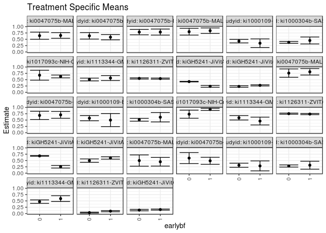

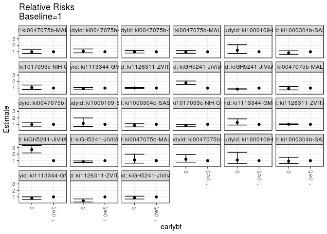

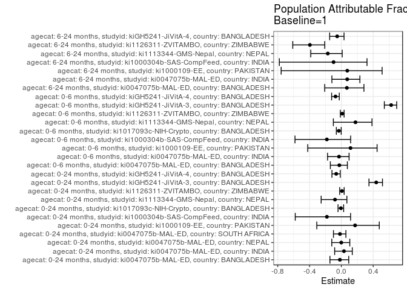

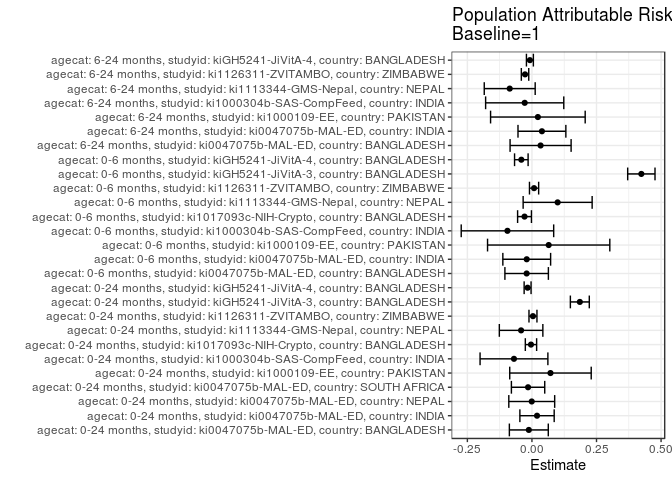

## Results Table

### Parameter: TSM

| agecat | studyid | country | intervention_level | baseline_level | estimate | ci_lower | ci_upper |
| --- | --- | --- | --- | --- | --- | --- | --- |
| 0-24 months | ki0047075b-MAL-ED | BANGLADESH | 1 | NA | 0.6513871 | 0.5397525 | 0.7630218 |
| 0-24 months | ki0047075b-MAL-ED | BANGLADESH | 0 | NA | 0.6424022 | 0.5012892 | 0.7835153 |
| 0-24 months | ki0047075b-MAL-ED | INDIA | 1 | NA | 0.5813934 | 0.4779050 | 0.6848818 |
| 0-24 months | ki0047075b-MAL-ED | INDIA | 0 | NA | 0.6362303 | 0.5082091 | 0.7642515 |
| 0-24 months | ki0047075b-MAL-ED | NEPAL | 1 | NA | 0.7857143 | 0.6655613 | 0.9058673 |
| 0-24 months | ki0047075b-MAL-ED | NEPAL | 0 | NA | 0.7843137 | 0.6765475 | 0.8920799 |
| 0-24 months | ki0047075b-MAL-ED | SOUTH AFRICA | 1 | NA | 0.8400000 | 0.7318211 | 0.9481789 |
| 0-24 months | ki0047075b-MAL-ED | SOUTH AFRICA | 0 | NA | 0.8000000 | 0.6657395 | 0.9342605 |
| 0-24 months | ki1000109-EE | PAKISTAN | 1 | NA | 0.3445807 | 0.1748500 | 0.5143114 |
| 0-24 months | ki1000109-EE | PAKISTAN | 0 | NA | 0.4266777 | 0.3560815 | 0.4972739 |
| 0-24 months | ki1000304b-SAS-CompFeed | INDIA | 1 | NA | 0.4522576 | 0.3155993 | 0.5889159 |
| 0-24 months | ki1000304b-SAS-CompFeed | INDIA | 0 | NA | 0.3778373 | 0.3412853 | 0.4143893 |
| 0-24 months | ki1017093c-NIH-Crypto | BANGLADESH | 1 | NA | 0.6275150 | 0.5713351 | 0.6836950 |
| 0-24 months | ki1017093c-NIH-Crypto | BANGLADESH | 0 | NA | 0.6771541 | 0.4802690 | 0.8740392 |
| 0-24 months | ki1113344-GMS-Nepal | NEPAL | 1 | NA | 0.5647610 | 0.4662155 | 0.6633066 |
| 0-24 months | ki1113344-GMS-Nepal | NEPAL | 0 | NA | 0.5077328 | 0.4531557 | 0.5623099 |
| 0-24 months | ki1126311-ZVITAMBO | ZIMBABWE | 1 | NA | 0.5432973 | 0.5200762 | 0.5665185 |
| 0-24 months | ki1126311-ZVITAMBO | ZIMBABWE | 0 | NA | 0.5493916 | 0.5268444 | 0.5719388 |
| 0-24 months | kiGH5241-JiVitA-3 | BANGLADESH | 1 | NA | 0.2373752 | 0.2016367 | 0.2731137 |
| 0-24 months | kiGH5241-JiVitA-3 | BANGLADESH | 0 | NA | 0.4242891 | 0.4129239 | 0.4356542 |
| 0-24 months | kiGH5241-JiVitA-4 | BANGLADESH | 1 | NA | 0.2753749 | 0.2517293 | 0.2990206 |
| 0-24 months | kiGH5241-JiVitA-4 | BANGLADESH | 0 | NA | 0.2327372 | 0.2022263 | 0.2632480 |
| 0-6 months | ki0047075b-MAL-ED | BANGLADESH | 1 | NA | 0.8108108 | 0.6847315 | 0.9368901 |
| 0-6 months | ki0047075b-MAL-ED | BANGLADESH | 0 | NA | 0.7600000 | 0.5939976 | 0.9260024 |
| 0-6 months | ki0047075b-MAL-ED | INDIA | 1 | NA | 0.7069020 | 0.5718187 | 0.8419853 |
| 0-6 months | ki0047075b-MAL-ED | INDIA | 0 | NA | 0.6850096 | 0.5210211 | 0.8489981 |
| 0-6 months | ki1000109-EE | PAKISTAN | 1 | NA | 0.5000000 | 0.2418553 | 0.7581447 |
| 0-6 months | ki1000109-EE | PAKISTAN | 0 | NA | 0.5760870 | 0.4734543 | 0.6787196 |
| 0-6 months | ki1000304b-SAS-CompFeed | INDIA | 1 | NA | 0.6140894 | 0.4268111 | 0.8013676 |
| 0-6 months | ki1000304b-SAS-CompFeed | INDIA | 0 | NA | 0.5133891 | 0.4570412 | 0.5697370 |
| 0-6 months | ki1017093c-NIH-Crypto | BANGLADESH | 1 | NA | 0.9226190 | 0.8817191 | 0.9635190 |
| 0-6 months | ki1017093c-NIH-Crypto | BANGLADESH | 0 | NA | 0.7333333 | 0.5730670 | 0.8935997 |
| 0-6 months | ki1113344-GMS-Nepal | NEPAL | 1 | NA | 0.4614550 | 0.3071156 | 0.6157944 |
| 0-6 months | ki1113344-GMS-Nepal | NEPAL | 0 | NA | 0.5902526 | 0.5023499 | 0.6781553 |
| 0-6 months | ki1126311-ZVITAMBO | ZIMBABWE | 1 | NA | 0.7378384 | 0.7124611 | 0.7632158 |
| 0-6 months | ki1126311-ZVITAMBO | ZIMBABWE | 0 | NA | 0.7534284 | 0.7303826 | 0.7764742 |
| 0-6 months | kiGH5241-JiVitA-3 | BANGLADESH | 1 | NA | 0.2528584 | 0.2003679 | 0.3053489 |
| 0-6 months | kiGH5241-JiVitA-3 | BANGLADESH | 0 | NA | 0.6810622 | 0.6675116 | 0.6946128 |
| 0-6 months | kiGH5241-JiVitA-4 | BANGLADESH | 1 | NA | 0.5998291 | 0.5535819 | 0.6460762 |
| 0-6 months | kiGH5241-JiVitA-4 | BANGLADESH | 0 | NA | 0.4943062 | 0.4272881 | 0.5613242 |
| 6-24 months | ki0047075b-MAL-ED | BANGLADESH | 1 | NA | 0.4498101 | 0.2781359 | 0.6214842 |
| 6-24 months | ki0047075b-MAL-ED | BANGLADESH | 0 | NA | 0.4967980 | 0.2746896 | 0.7189064 |
| 6-24 months | ki0047075b-MAL-ED | INDIA | 1 | NA | 0.4876474 | 0.3486119 | 0.6266828 |
| 6-24 months | ki0047075b-MAL-ED | INDIA | 0 | NA | 0.5949383 | 0.3781387 | 0.8117378 |
| 6-24 months | ki1000109-EE | PAKISTAN | 1 | NA | 0.2857143 | 0.0885683 | 0.4828603 |
| 6-24 months | ki1000109-EE | PAKISTAN | 0 | NA | 0.3125000 | 0.2313361 | 0.3936639 |
| 6-24 months | ki1000304b-SAS-CompFeed | INDIA | 1 | NA | 0.3134346 | 0.1564674 | 0.4704018 |
| 6-24 months | ki1000304b-SAS-CompFeed | INDIA | 0 | NA | 0.2823305 | 0.2390692 | 0.3255917 |
| 6-24 months | ki1113344-GMS-Nepal | NEPAL | 1 | NA | 0.5904168 | 0.4767959 | 0.7040378 |
| 6-24 months | ki1113344-GMS-Nepal | NEPAL | 0 | NA | 0.4712896 | 0.4034472 | 0.5391320 |
| 6-24 months | ki1126311-ZVITAMBO | ZIMBABWE | 1 | NA | 0.0942207 | 0.0694400 | 0.1190014 |
| 6-24 months | ki1126311-ZVITAMBO | ZIMBABWE | 0 | NA | 0.0358535 | 0.0173006 | 0.0544065 |
| 6-24 months | kiGH5241-JiVitA-4 | BANGLADESH | 1 | NA | 0.1569576 | 0.1346399 | 0.1792754 |
| 6-24 months | kiGH5241-JiVitA-4 | BANGLADESH | 0 | NA | 0.1356589 | 0.1069782 | 0.1643396 |

### Parameter: E(Y)

| agecat | studyid | country | intervention_level | baseline_level | estimate | ci_lower | ci_upper |
| --- | --- | --- | --- | --- | --- | --- | --- |
| 0-24 months | ki0047075b-MAL-ED | BANGLADESH | NA | NA | 0.6393443 | 0.5524803 | 0.7262082 |
| 0-24 months | ki0047075b-MAL-ED | INDIA | NA | NA | 0.6011236 | 0.5212729 | 0.6809743 |
| 0-24 months | ki0047075b-MAL-ED | NEPAL | NA | NA | 0.7849462 | 0.7049947 | 0.8648978 |
| 0-24 months | ki0047075b-MAL-ED | SOUTH AFRICA | NA | NA | 0.8250000 | 0.7407860 | 0.9092140 |
| 0-24 months | ki1000109-EE | PAKISTAN | NA | NA | 0.4163424 | 0.3511349 | 0.4815500 |
| 0-24 months | ki1000304b-SAS-CompFeed | INDIA | NA | NA | 0.3827160 | 0.3474971 | 0.4179350 |
| 0-24 months | ki1017093c-NIH-Crypto | BANGLADESH | NA | NA | 0.6237942 | 0.5698223 | 0.6777662 |
| 0-24 months | ki1113344-GMS-Nepal | NEPAL | NA | NA | 0.5227723 | 0.4753649 | 0.5701796 |
| 0-24 months | ki1126311-ZVITAMBO | ZIMBABWE | NA | NA | 0.5472806 | 0.5299898 | 0.5645714 |
| 0-24 months | kiGH5241-JiVitA-3 | BANGLADESH | NA | NA | 0.4228126 | 0.4116855 | 0.4339397 |
| 0-24 months | kiGH5241-JiVitA-4 | BANGLADESH | NA | NA | 0.2585790 | 0.2392503 | 0.2779077 |
| 0-6 months | ki0047075b-MAL-ED | BANGLADESH | NA | NA | 0.7903226 | 0.6894772 | 0.8911679 |
| 0-6 months | ki0047075b-MAL-ED | INDIA | NA | NA | 0.6867470 | 0.5837430 | 0.7897510 |
| 0-6 months | ki1000109-EE | PAKISTAN | NA | NA | 0.5648148 | 0.4692893 | 0.6603404 |
| 0-6 months | ki1000304b-SAS-CompFeed | INDIA | NA | NA | 0.5192878 | 0.4654446 | 0.5731311 |
| 0-6 months | ki1017093c-NIH-Crypto | BANGLADESH | NA | NA | 0.8939394 | 0.8505280 | 0.9373508 |
| 0-6 months | ki1113344-GMS-Nepal | NEPAL | NA | NA | 0.5609756 | 0.4845156 | 0.6374356 |
| 0-6 months | ki1126311-ZVITAMBO | ZIMBABWE | NA | NA | 0.7460664 | 0.7282412 | 0.7638917 |
| 0-6 months | kiGH5241-JiVitA-3 | BANGLADESH | NA | NA | 0.6764644 | 0.6631306 | 0.6897982 |
| 0-6 months | kiGH5241-JiVitA-4 | BANGLADESH | NA | NA | 0.5587703 | 0.5173487 | 0.6001920 |
| 6-24 months | ki0047075b-MAL-ED | BANGLADESH | NA | NA | 0.4833333 | 0.3508378 | 0.6158289 |
| 6-24 months | ki0047075b-MAL-ED | INDIA | NA | NA | 0.5263158 | 0.4116286 | 0.6410029 |
| 6-24 months | ki1000109-EE | PAKISTAN | NA | NA | 0.3087248 | 0.2336906 | 0.3837591 |
| 6-24 months | ki1000304b-SAS-CompFeed | INDIA | NA | NA | 0.2854123 | 0.2436284 | 0.3271961 |
| 6-24 months | ki1113344-GMS-Nepal | NEPAL | NA | NA | 0.5043988 | 0.4461732 | 0.5626244 |
| 6-24 months | ki1126311-ZVITAMBO | ZIMBABWE | NA | NA | 0.0675105 | 0.0516864 | 0.0833347 |
| 6-24 months | kiGH5241-JiVitA-4 | BANGLADESH | NA | NA | 0.1490765 | 0.1314900 | 0.1666630 |

### Parameter: RR

| agecat | studyid | country | intervention_level | baseline_level | estimate | ci_lower | ci_upper |
| --- | --- | --- | --- | --- | --- | --- | --- |
| 0-24 months | ki0047075b-MAL-ED | BANGLADESH | 1 | 1 | 1.0000000 | 1.0000000 | 1.0000000 |
| 0-24 months | ki0047075b-MAL-ED | BANGLADESH | 0 | 1 | 0.9862065 | 0.7415547 | 1.3115733 |
| 0-24 months | ki0047075b-MAL-ED | INDIA | 1 | 1 | 1.0000000 | 1.0000000 | 1.0000000 |
| 0-24 months | ki0047075b-MAL-ED | INDIA | 0 | 1 | 1.0943197 | 0.8361238 | 1.4322469 |
| 0-24 months | ki0047075b-MAL-ED | NEPAL | 1 | 1 | 1.0000000 | 1.0000000 | 1.0000000 |
| 0-24 months | ki0047075b-MAL-ED | NEPAL | 0 | 1 | 0.9982175 | 0.8121387 | 1.2269310 |
| 0-24 months | ki0047075b-MAL-ED | SOUTH AFRICA | 1 | 1 | 1.0000000 | 1.0000000 | 1.0000000 |
| 0-24 months | ki0047075b-MAL-ED | SOUTH AFRICA | 0 | 1 | 0.9523810 | 0.7706578 | 1.1769549 |
| 0-24 months | ki1000109-EE | PAKISTAN | 1 | 1 | 1.0000000 | 1.0000000 | 1.0000000 |
| 0-24 months | ki1000109-EE | PAKISTAN | 0 | 1 | 1.2382520 | 0.7348771 | 2.0864277 |
| 0-24 months | ki1000304b-SAS-CompFeed | INDIA | 1 | 1 | 1.0000000 | 1.0000000 | 1.0000000 |
| 0-24 months | ki1000304b-SAS-CompFeed | INDIA | 0 | 1 | 0.8354471 | 0.6086223 | 1.1468063 |
| 0-24 months | ki1017093c-NIH-Crypto | BANGLADESH | 1 | 1 | 1.0000000 | 1.0000000 | 1.0000000 |
| 0-24 months | ki1017093c-NIH-Crypto | BANGLADESH | 0 | 1 | 1.0791042 | 0.7961686 | 1.4625871 |
| 0-24 months | ki1113344-GMS-Nepal | NEPAL | 1 | 1 | 1.0000000 | 1.0000000 | 1.0000000 |
| 0-24 months | ki1113344-GMS-Nepal | NEPAL | 0 | 1 | 0.8990225 | 0.7321933 | 1.1038634 |
| 0-24 months | ki1126311-ZVITAMBO | ZIMBABWE | 1 | 1 | 1.0000000 | 1.0000000 | 1.0000000 |
| 0-24 months | ki1126311-ZVITAMBO | ZIMBABWE | 0 | 1 | 1.0112171 | 0.9575484 | 1.0678938 |
| 0-24 months | kiGH5241-JiVitA-3 | BANGLADESH | 1 | 1 | 1.0000000 | 1.0000000 | 1.0000000 |
| 0-24 months | kiGH5241-JiVitA-3 | BANGLADESH | 0 | 1 | 1.7874198 | 1.5337635 | 2.0830262 |
| 0-24 months | kiGH5241-JiVitA-4 | BANGLADESH | 1 | 1 | 1.0000000 | 1.0000000 | 1.0000000 |
| 0-24 months | kiGH5241-JiVitA-4 | BANGLADESH | 0 | 1 | 0.8451647 | 0.7268177 | 0.9827819 |
| 0-6 months | ki0047075b-MAL-ED | BANGLADESH | 1 | 1 | 1.0000000 | 1.0000000 | 1.0000000 |
| 0-6 months | ki0047075b-MAL-ED | BANGLADESH | 0 | 1 | 0.9373333 | 0.7168762 | 1.2255865 |
| 0-6 months | ki0047075b-MAL-ED | INDIA | 1 | 1 | 1.0000000 | 1.0000000 | 1.0000000 |
| 0-6 months | ki0047075b-MAL-ED | INDIA | 0 | 1 | 0.9690305 | 0.7118206 | 1.3191807 |
| 0-6 months | ki1000109-EE | PAKISTAN | 1 | 1 | 1.0000000 | 1.0000000 | 1.0000000 |
| 0-6 months | ki1000109-EE | PAKISTAN | 0 | 1 | 1.1521739 | 0.6673022 | 1.9893607 |
| 0-6 months | ki1000304b-SAS-CompFeed | INDIA | 1 | 1 | 1.0000000 | 1.0000000 | 1.0000000 |
| 0-6 months | ki1000304b-SAS-CompFeed | INDIA | 0 | 1 | 0.8360169 | 0.6046934 | 1.1558324 |
| 0-6 months | ki1017093c-NIH-Crypto | BANGLADESH | 1 | 1 | 1.0000000 | 1.0000000 | 1.0000000 |
| 0-6 months | ki1017093c-NIH-Crypto | BANGLADESH | 0 | 1 | 0.7948387 | 0.6359650 | 0.9934016 |
| 0-6 months | ki1113344-GMS-Nepal | NEPAL | 1 | 1 | 1.0000000 | 1.0000000 | 1.0000000 |
| 0-6 months | ki1113344-GMS-Nepal | NEPAL | 0 | 1 | 1.2791119 | 0.8861435 | 1.8463459 |
| 0-6 months | ki1126311-ZVITAMBO | ZIMBABWE | 1 | 1 | 1.0000000 | 1.0000000 | 1.0000000 |
| 0-6 months | ki1126311-ZVITAMBO | ZIMBABWE | 0 | 1 | 1.0211292 | 0.9774327 | 1.0667792 |
| 0-6 months | kiGH5241-JiVitA-3 | BANGLADESH | 1 | 1 | 1.0000000 | 1.0000000 | 1.0000000 |
| 0-6 months | kiGH5241-JiVitA-3 | BANGLADESH | 0 | 1 | 2.6934532 | 2.1864824 | 3.3179734 |
| 0-6 months | kiGH5241-JiVitA-4 | BANGLADESH | 1 | 1 | 1.0000000 | 1.0000000 | 1.0000000 |
| 0-6 months | kiGH5241-JiVitA-4 | BANGLADESH | 0 | 1 | 0.8240784 | 0.7140793 | 0.9510221 |
| 6-24 months | ki0047075b-MAL-ED | BANGLADESH | 1 | 1 | 1.0000000 | 1.0000000 | 1.0000000 |
| 6-24 months | ki0047075b-MAL-ED | BANGLADESH | 0 | 1 | 1.1044617 | 0.6126774 | 1.9909917 |
| 6-24 months | ki0047075b-MAL-ED | INDIA | 1 | 1 | 1.0000000 | 1.0000000 | 1.0000000 |
| 6-24 months | ki0047075b-MAL-ED | INDIA | 0 | 1 | 1.2200174 | 0.7656422 | 1.9440444 |
| 6-24 months | ki1000109-EE | PAKISTAN | 1 | 1 | 1.0000000 | 1.0000000 | 1.0000000 |
| 6-24 months | ki1000109-EE | PAKISTAN | 0 | 1 | 1.0937500 | 0.5231204 | 2.2868333 |
| 6-24 months | ki1000304b-SAS-CompFeed | INDIA | 1 | 1 | 1.0000000 | 1.0000000 | 1.0000000 |
| 6-24 months | ki1000304b-SAS-CompFeed | INDIA | 0 | 1 | 0.9007635 | 0.5340988 | 1.5191477 |
| 6-24 months | ki1113344-GMS-Nepal | NEPAL | 1 | 1 | 1.0000000 | 1.0000000 | 1.0000000 |
| 6-24 months | ki1113344-GMS-Nepal | NEPAL | 0 | 1 | 0.7982320 | 0.6276076 | 1.0152430 |
| 6-24 months | ki1126311-ZVITAMBO | ZIMBABWE | 1 | 1 | 1.0000000 | 1.0000000 | 1.0000000 |
| 6-24 months | ki1126311-ZVITAMBO | ZIMBABWE | 0 | 1 | 0.3805272 | 0.2129774 | 0.6798889 |
| 6-24 months | kiGH5241-JiVitA-4 | BANGLADESH | 1 | 1 | 1.0000000 | 1.0000000 | 1.0000000 |
| 6-24 months | kiGH5241-JiVitA-4 | BANGLADESH | 0 | 1 | 0.8643026 | 0.6698267 | 1.1152422 |

### Parameter: PAR

| agecat | studyid | country | intervention_level | baseline_level | estimate | ci_lower | ci_upper |
| --- | --- | --- | --- | --- | --- | --- | --- |
| 0-24 months | ki0047075b-MAL-ED | BANGLADESH | 1 | NA | -0.0120429 | -0.0873963 | 0.0633106 |
| 0-24 months | ki0047075b-MAL-ED | INDIA | 1 | NA | 0.0197302 | -0.0466780 | 0.0861383 |
| 0-24 months | ki0047075b-MAL-ED | NEPAL | 1 | NA | -0.0007680 | -0.0895672 | 0.0880311 |
| 0-24 months | ki0047075b-MAL-ED | SOUTH AFRICA | 1 | NA | -0.0150000 | -0.0795179 | 0.0495179 |
| 0-24 months | ki1000109-EE | PAKISTAN | 1 | NA | 0.0717617 | -0.0859884 | 0.2295119 |
| 0-24 months | ki1000304b-SAS-CompFeed | INDIA | 1 | NA | -0.0695415 | -0.2008114 | 0.0617283 |
| 0-24 months | ki1017093c-NIH-Crypto | BANGLADESH | 1 | NA | -0.0037208 | -0.0256118 | 0.0181702 |
| 0-24 months | ki1113344-GMS-Nepal | NEPAL | 1 | NA | -0.0419887 | -0.1262425 | 0.0422650 |
| 0-24 months | ki1126311-ZVITAMBO | ZIMBABWE | 1 | NA | 0.0039833 | -0.0114490 | 0.0194155 |
| 0-24 months | kiGH5241-JiVitA-3 | BANGLADESH | 1 | NA | 0.1854374 | 0.1487981 | 0.2220767 |
| 0-24 months | kiGH5241-JiVitA-4 | BANGLADESH | 1 | NA | -0.0167959 | -0.0302025 | -0.0033894 |
| 0-6 months | ki0047075b-MAL-ED | BANGLADESH | 1 | NA | -0.0204882 | -0.1046649 | 0.0636884 |
| 0-6 months | ki0047075b-MAL-ED | INDIA | 1 | NA | -0.0201551 | -0.1126436 | 0.0723335 |
| 0-6 months | ki1000109-EE | PAKISTAN | 1 | NA | 0.0648148 | -0.1718685 | 0.3014982 |
| 0-6 months | ki1000304b-SAS-CompFeed | INDIA | 1 | NA | -0.0948016 | -0.2737858 | 0.0841827 |
| 0-6 months | ki1017093c-NIH-Crypto | BANGLADESH | 1 | NA | -0.0286797 | -0.0555072 | -0.0018521 |
| 0-6 months | ki1113344-GMS-Nepal | NEPAL | 1 | NA | 0.0995206 | -0.0340554 | 0.2330966 |
| 0-6 months | ki1126311-ZVITAMBO | ZIMBABWE | 1 | NA | 0.0082280 | -0.0095280 | 0.0259840 |
| 0-6 months | kiGH5241-JiVitA-3 | BANGLADESH | 1 | NA | 0.4236060 | 0.3707159 | 0.4764961 |
| 0-6 months | kiGH5241-JiVitA-4 | BANGLADESH | 1 | NA | -0.0410587 | -0.0672912 | -0.0148262 |
| 6-24 months | ki0047075b-MAL-ED | BANGLADESH | 1 | NA | 0.0335233 | -0.0846286 | 0.1516751 |
| 6-24 months | ki0047075b-MAL-ED | INDIA | 1 | NA | 0.0386684 | -0.0539949 | 0.1313318 |
| 6-24 months | ki1000109-EE | PAKISTAN | 1 | NA | 0.0230105 | -0.1601382 | 0.2061593 |
| 6-24 months | ki1000304b-SAS-CompFeed | INDIA | 1 | NA | -0.0280223 | -0.1793298 | 0.1232852 |
| 6-24 months | ki1113344-GMS-Nepal | NEPAL | 1 | NA | -0.0860180 | -0.1846124 | 0.0125764 |
| 6-24 months | ki1126311-ZVITAMBO | ZIMBABWE | 1 | NA | -0.0267102 | -0.0410696 | -0.0123507 |
| 6-24 months | kiGH5241-JiVitA-4 | BANGLADESH | 1 | NA | -0.0078811 | -0.0213147 | 0.0055524 |

### Parameter: PAF

| agecat | studyid | country | intervention_level | baseline_level | estimate | ci_lower | ci_upper |
| --- | --- | --- | --- | --- | --- | --- | --- |
| 0-24 months | ki0047075b-MAL-ED | BANGLADESH | 1 | NA | -0.0188363 | -0.1439827 | 0.0926197 |
| 0-24 months | ki0047075b-MAL-ED | INDIA | 1 | NA | 0.0328222 | -0.0842689 | 0.1372685 |
| 0-24 months | ki0047075b-MAL-ED | NEPAL | 1 | NA | -0.0009785 | -0.1207455 | 0.1059898 |
| 0-24 months | ki0047075b-MAL-ED | SOUTH AFRICA | 1 | NA | -0.0181818 | -0.0994081 | 0.0570433 |
| 0-24 months | ki1000109-EE | PAKISTAN | 1 | NA | 0.1723623 | -0.3090006 | 0.4767121 |
| 0-24 months | ki1000304b-SAS-CompFeed | INDIA | 1 | NA | -0.1817053 | -0.5797189 | 0.1160279 |
| 0-24 months | ki1017093c-NIH-Crypto | BANGLADESH | 1 | NA | -0.0059648 | -0.0417347 | 0.0285768 |
| 0-24 months | ki1113344-GMS-Nepal | NEPAL | 1 | NA | -0.0803194 | -0.2539338 | 0.0692571 |
| 0-24 months | ki1126311-ZVITAMBO | ZIMBABWE | 1 | NA | 0.0072783 | -0.0213260 | 0.0350814 |
| 0-24 months | kiGH5241-JiVitA-3 | BANGLADESH | 1 | NA | 0.4385807 | 0.3471253 | 0.5172249 |
| 0-24 months | kiGH5241-JiVitA-4 | BANGLADESH | 1 | NA | -0.0649547 | -0.1182660 | -0.0141849 |
| 0-6 months | ki0047075b-MAL-ED | BANGLADESH | 1 | NA | -0.0259239 | -0.1385086 | 0.0755276 |
| 0-6 months | ki0047075b-MAL-ED | INDIA | 1 | NA | -0.0293486 | -0.1735554 | 0.0971380 |
| 0-6 months | ki1000109-EE | PAKISTAN | 1 | NA | 0.1147541 | -0.4229150 | 0.4492571 |
| 0-6 months | ki1000304b-SAS-CompFeed | INDIA | 1 | NA | -0.1825607 | -0.5832333 | 0.1167127 |
| 0-6 months | ki1017093c-NIH-Crypto | BANGLADESH | 1 | NA | -0.0320823 | -0.0632092 | -0.0018667 |
| 0-6 months | ki1113344-GMS-Nepal | NEPAL | 1 | NA | 0.1774063 | -0.1005959 | 0.3851872 |
| 0-6 months | ki1126311-ZVITAMBO | ZIMBABWE | 1 | NA | 0.0110285 | -0.0130658 | 0.0345498 |
| 0-6 months | kiGH5241-JiVitA-3 | BANGLADESH | 1 | NA | 0.6262059 | 0.5404184 | 0.6959800 |
| 0-6 months | kiGH5241-JiVitA-4 | BANGLADESH | 1 | NA | -0.0734805 | -0.1224833 | -0.0266169 |
| 6-24 months | ki0047075b-MAL-ED | BANGLADESH | 1 | NA | 0.0693585 | -0.2095523 | 0.2839552 |
| 6-24 months | ki0047075b-MAL-ED | INDIA | 1 | NA | 0.0734700 | -0.1191126 | 0.2329120 |
| 6-24 months | ki1000109-EE | PAKISTAN | 1 | NA | 0.0745342 | -0.7570615 | 0.5125458 |
| 6-24 months | ki1000304b-SAS-CompFeed | INDIA | 1 | NA | -0.0981820 | -0.7799316 | 0.3224438 |
| 6-24 months | ki1113344-GMS-Nepal | NEPAL | 1 | NA | -0.1705357 | -0.3848482 | 0.0106108 |
| 6-24 months | ki1126311-ZVITAMBO | ZIMBABWE | 1 | NA | -0.3956443 | -0.6111740 | -0.2089463 |
| 6-24 months | kiGH5241-JiVitA-4 | BANGLADESH | 1 | NA | -0.0528663 | -0.1470619 | 0.0335940 |